# Coursework Report

*N* removed NAs: 4

*N* removed <18: 33

*N* total clean: 130

| Group | *N* | *M*<sub>age</sub> | % green |
| --- | --- | --- | --- |
| Control | 66 | 20.7 | 37.9 |
| Experim | 64 | 20.5 | 56.2 |

[output not shown]

**Main analysis results**

**car:**  
χ<sup>2</sup>(1) = 3.71, *p* = .054

**cleaner:**  
χ<sup>2</sup>(1) = 1.51, *p* = .219

# Coursework Report

Analysing Data, Spring 2020

```
##     id_code       gender       years                  condition         product      category
##  ADJX   :  3   female:252   Length:504         contro      :  1   car       :168   luxury:265
##  AELQ   :  3   male  :171   Class :character   control     :251   dishwasher:168   green :239
##  ALBO   :  3   other : 81   Mode  :character   experimental:252   cleaner   :168
##  ALKC   :  3
##  AOXY   :  3
##  ARGJ   :  3
##  (Other):486
```

```
## .
## 13 14 15 16 17 18 19 1u 20 21 22 23 24 25  4
##  6  6 21 24 42 60 74  1 69 69 48 21 36 12  3
```

[output not shown]

```
##     id_code       gender        years              condition         product      category
##  ADJX   :  3   male  :243   Min.   :  4.0   control     :246   car       :164   luxury:259
##  AELQ   :  3   female:168   1st Qu.: 18.0   experimental:246   dishwasher:164   green :233
##  ALBO   :  3   other : 81   Median : 20.0                      cleaner   :164
##  ALKC   :  3                Mean   : 19.7
##  AOXY   :  3                3rd Qu.: 21.0
##  ARGJ   :  3                Max.   :100.0
##  (Other):474
```

```
## .
##   4  13  14  15  16  17  18  19  20  21  22  23  24  25 100
##   3   6   6  21  24  42  60  74  69  69  48  21  36  12   1
```

Summary of Participants Demographics by Experimental Condition

| Gender | Condition | Count | *M*<sub>age</sub> | *SD*<sub>age</sub> |
| --- | --- | --- | --- | --- |
| male | control | 102 | 20.4 | 1.97 |
| male | experimental | 89 | 20.7 | 2.12 |
| female | control | 78 | 20.7 | 1.71 |
| female | experimental | 48 | 20.0 | 2.17 |
| other | control | 18 | 22.0 | 1.19 |
| other | experimental | 54 | 20.7 | 1.84 |

Observed Frequencies of Car Product Choices by Story Type

|  | luxury | green |
| --- | --- | --- |
| control | 44 | 22 |
| experimental | 31 | 33 |

Observed Frequencies of Dishwasher Product Choices by Story Type

|  | luxury | green |
| --- | --- | --- |
| control | 42 | 24 |
| experimental | 25 | 38 |

Observed Frequencies of Cleaner Product Choices by Story Type

|  | luxury | green |
| --- | --- | --- |
| control | 37 | 29 |
| experimental | 28 | 36 |

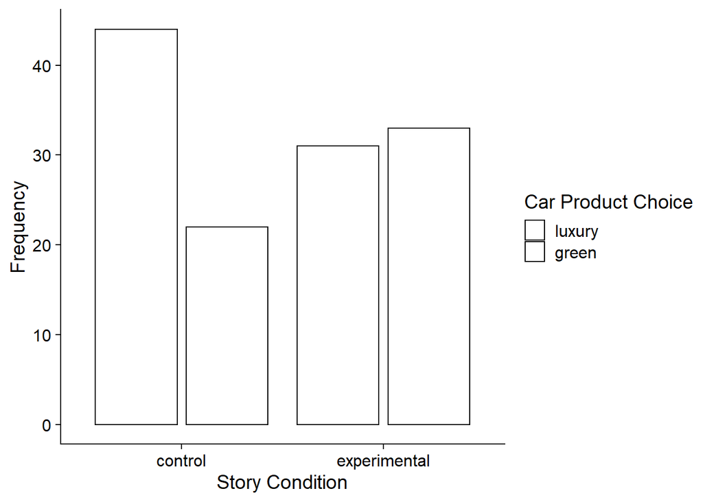

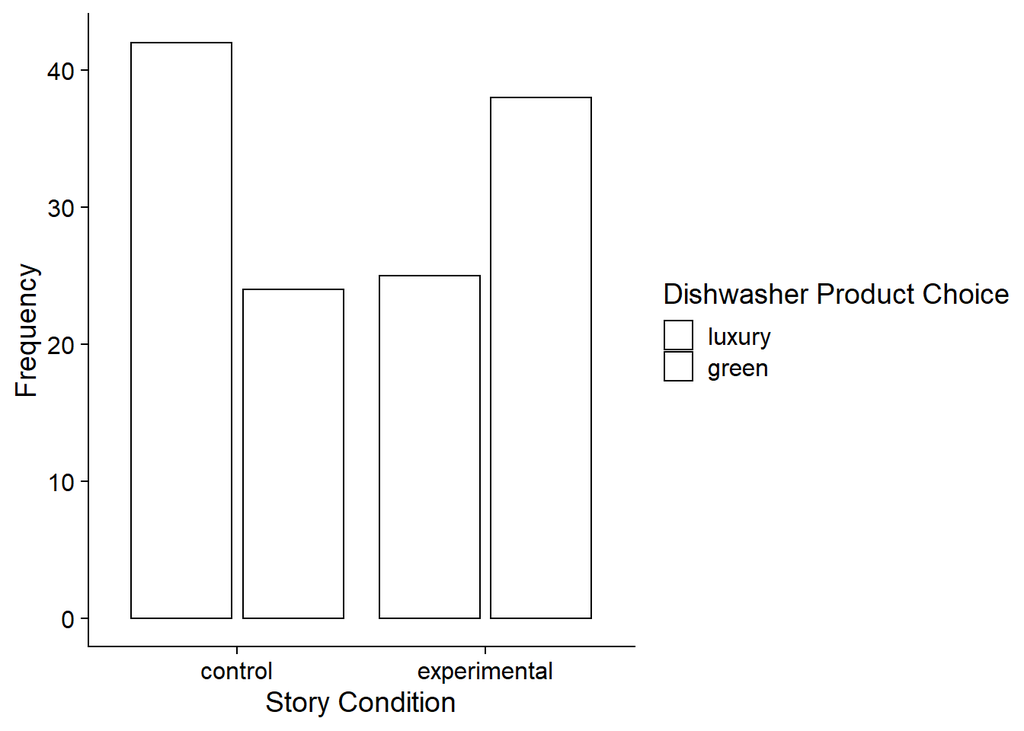

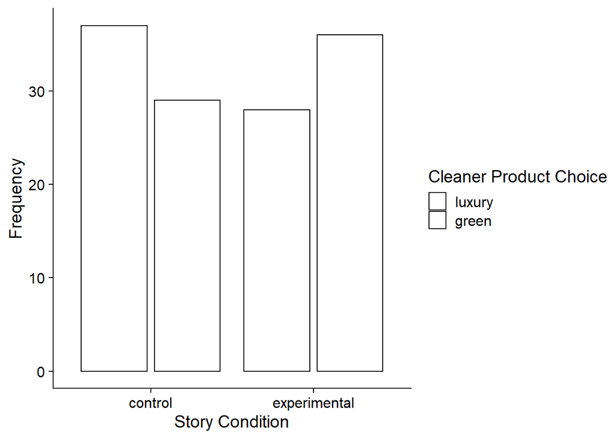

Expected Frequencies of Car Product Choices by Story Type

|  | luxury | green |
| --- | --- | --- |
| control | 38.1 | 27.9 |
| experimental | 36.9 | 27.1 |

```
##
##  Pearson's Chi-squared test with Yates' continuity correction
##
## data:  car_choice_tab
## X-squared = 4, df = 1, p-value = 0.05
```

Expected Frequencies of Dishwasher Product Choices by Story Type

|  | luxury | green |
| --- | --- | --- |
| control | 34.3 | 31.7 |
| experimental | 32.7 | 30.3 |

```
##
##  Pearson's Chi-squared test with Yates' continuity correction
##
## data:  dishwasher_choice_tab
## X-squared = 6, df = 1, p-value = 0.01
```

Expected Frequencies of Cleaner Product Choices by Story Type

|  | luxury | green |
| --- | --- | --- |
| control | 33 | 33 |
| experimental | 32 | 32 |

```
##
##  Pearson's Chi-squared test with Yates' continuity correction
##
## data:  cleaner_choice_tab
## X-squared = 2, df = 1, p-value = 0.2
```

# Methods

## Participants

Table 1: Summary of Participants Demographics by Experimental Condition

| Gender | Condition | Count | *M*<sub>age</sub> | *SD*<sub>age</sub> |
| --- | --- | --- | --- | --- |
| male | control | 102 | 20.4 | 1.97 |
| male | experimental | 89 | 20.7 | 2.12 |
| female | control | 78 | 20.7 | 1.71 |
| female | experimental | 48 | 20.0 | 2.17 |
| other | control | 18 | 22.0 | 1.19 |
| other | experimental | 54 | 20.7 | 1.84 |

## Design

In this study we examined whether status motives influence “green” purchases. In order to investigate this research question, a between subjects design was used in which there were two motive conditions: status and control. Participants were randomly allocated to each of these conditions. In the status group, participants were asked to read a short story which had been proven to elicit status motives in previous research (see Griskevicius, Tybur, et al., 2009) while the participants in the control condition read a story of a similar length unrelated to status. After this motive manipulation, participants were then asked to choose between green and more luxurious non green alternatives of the following products: car, cleaner, dishwasher. Data was collected from each participant concerning whether they had chosen the green or non green alternative for each product. Increased choice of green products from the high-status group compared to the control story group would suggest that green product choice is associated with status motives. Therefore our operational hypothesis was whether reading a high-status story versus the control story would be associated with the frequency of green product versus non-green product choice. In order to test this operational hypothesis Chi-Squared tests will be used to measure the association between motive condition and product choice.

# Results

Participants’ product choices were analysed by condition. For each product, similar findings were found with the status motivated group showing a greater preference for green products in comparison to the control group. As Table 2 shows, 51.56% of participants who read the status story chose the green car over the non green car while only 33.33% of participants who read the control story made the same choice. Similar findings were observed when participants were asked to choose between green and non green dishwashers and cleaners. Table 3 shows that 60.32% of the status motivated group chose the green dishwasher over the luxury non green dishwasher while only 36.36% of the control group did. Consistent with these findings Table 4 shows that 56.25% of the status motivated group chose the green cleaner while only 43.93% of the control group chose the same. The graphs below also visually represent this trend of greater preference for green products in the high status condition, but not in the control group.

Table 2: Observed Frequencies of Car Product Choices by Story Type

|  | luxury | green |
| --- | --- | --- |
| control | 44 | 22 |
| experimental | 31 | 33 |

Table 3: Observed Frequencies of Dishwasher Product Choices by Story Type

|  | luxury | green |
| --- | --- | --- |
| control | 42 | 24 |
| experimental | 25 | 38 |

Table 4: Observed Frequencies of Cleaner Product Choices by Story Type

|  | luxury | green |
| --- | --- | --- |
| control | 37 | 29 |
| experimental | 28 | 36 |

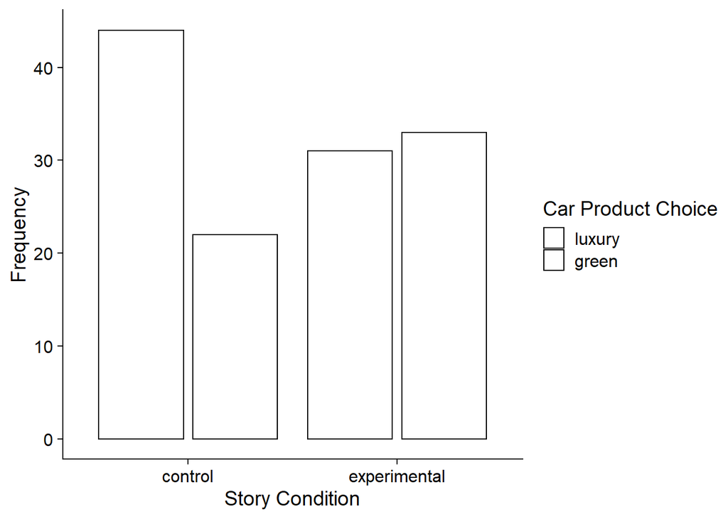

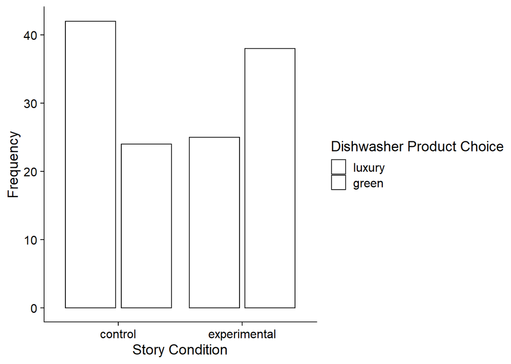

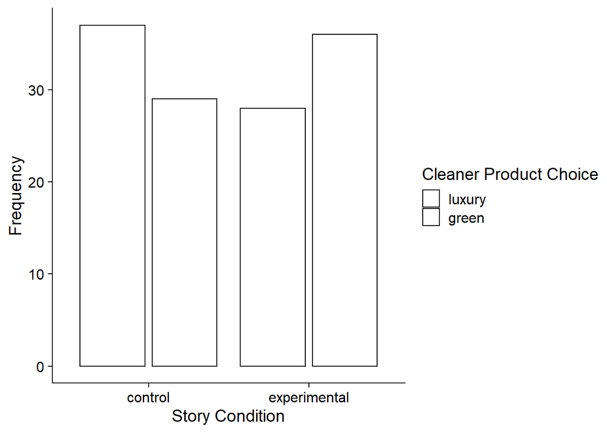

## Analysis

We performed an chi-squared analyses to investigate whether product choice (green versus non-green product) was associated with motive condition (status motivated versus control). The analysis showed that there was a significant association between dishwasher product choice and motive condition, *χ*<sup>2</sup>(1) = 6.48, *p* = 0.011, however a significant association was not revealed between car product choice and motive condition *χ*<sup>2</sup>(1) = 3.71, *p* = 0.054, and cleaner product choice and motive condition *χ*<sup>2</sup>(1) = 1.51, *p* = 0.219.

# Discussion

The results of this study presented the status motivated group to have a greater preference towards green products while the control group showed a greater preference for non-green, luxury products. This was evidently displayed as 60.32% of the status motivated group chose the green dishwasher over the luxury non green dishwasher while only 36.36% of the control group made the same choice. Our statistical analysis suggested that this association between product preference and status motivation was significant when participants chose between dishwashers but not for cleaners and cars. Our findings are similar to those of the study conducted by (Griskevicius et al., 2009) which our experiment aimed to replicate.

In the original study, the researchers found a comparable trend that 54.5% of participants chose the green car in the status condition, while only 37.3% chose it in the control condition. This similar pattern of results suggests that we have effectively replicated the study and subsequently implies that there may be an association between status motivation and green product preference as our current study can be added to body of evidence for this association.

When looking at the existing literature, many studies have found similar patterns of results, giving solid evidence for an association between status motivation and green product consumption (Berger,2019; Griskevicius et al., 2009 & Johnson et al.,2018). Concerning pathways for future research, researchers could now extend these findings and for example, research whether status motives can influence purchases beyond green goods, such as the consumption of athletic products to increase status for those who value being athletic, or the consumption of beauty products to increase status for those who value appearance. In order to conduct these kinds of studies existing populations will need to be used rather than experimental manipulation of groups.

Concerning the current study, it has many strengths, which enables it to effectively support the hypothesis that high status motivates people to buy green products. Firstly the use of a large sample size was a great strength as it allowed us to collect a sample which was representative, therefore allowing our results to be extrapolated to the wider population (Biau et al., 2008). Furthermore this large sample size allowed us to increase the statistical significance of our evidence for the effects of status motives on product preference (Anderson et al., 2017). Secondly, our use of a between subjects design was a further strength of the study as it allowed comparisons to be made between the high status story group and control group (Charness et al., 2012). Furthermore as we randomly assigned participants to each condition we were able to reduce the effect of confounding variables, therefore allowing us to assume that any differences in product preferences between the two groups would be due to status motives only. However, a limitation of this study was that it did not involve participants actually purchasing products and this might have influenced product preference. However, as this study was a direct replication of the study conducted by Griskevicius et al., 2009 there is significant evidence that the findings of the current study would also be replicated in actual behaviour as the product choice findings of the original study conducted by Griskevicius et al., 2009 coincided well with self-report data on the reasons for people purchasing green products (Maynard, 2007). Therefore I would conclude that status motives are associated with green product preference as our replication was well controlled and efectively designed, suggesting that the association that we found was reliable.

# References

Anderson, S. F., Kelley, K., & Maxwell, S. E. (2017). Sample-Size Planning for More Accurate Statistical Power: A Method Adjusting Sample Effect Sizes for Publication Bias and Uncertainty. Psychological Science, 28(11), 1547–1562. https://doi.org/10.1177/0956797617723724.

Berger, J. (2019). Signaling can increase consumers’ willingness to pay for green products. Theoretical model and experimental evidence. Journal of Consumer Behaviour, 18(3), 233–246. https://doi.org/10.1002/cb.1760.

Biau, D. J., Kernéis, S., & Porcher, R. (2008). Statistics in Brief: The Importance of Sample Size in the Planning and Interpretation of Medical Research. Clinical Orthopaedics and Related Research, 466(9), 2282–2288. https://doi.org/10.1007/s11999-008-0346-9.

Charness, G., Gneezy, U., & Kuhn, M. A. (2012). Experimental methods: Between-subject and within-subject design. Journal of Economic Behavior & Organization, 81(1), 1–8. https://doi.org/10.1016/j.jebo.2011.08.009.

Griskevicius, V., Tybur, J. M., & Van den Bergh, B. (2010). Going Green to Be Seen: Status, Reputation, and Conspicuous Conservation. Journal of Personality and Social Psychology, 98(3), 392–404. https://doi.org/10.1037/a0017346.

Johnson, C. M., Tariq, A., & Baker, T. L. (2018). From Gucci to Green Bags: Conspicuous Consumption as a Signal for Pro-Social Behavior. Journal of Marketing Theory and Practice, 26(4), 339–356. https://doi.org/10.1080/10696679.2018.1487769.

Maynard, M. (2007, July 4). Say ‘Hybrid’ and Many People Will Hear ‘Prius’. The New York Times. Retrieved from https://www.nytimes.com/2007/07/04/business/04hybrid.html.